# Predicting Home Selling Price in Ames, Iowa

Darek Davis

October 08, 2020

## 0.1 Overview

In this analysis I attempt to build a stepwise regression model capable of predicting the selling price of a given home in Ames, Iowa based on house characteristics to aid local realtors when pricing a house for clients or acquisitions. This model will also allow realtors to see which characteristics influence home prices to faciliate customer conversations. Furthermore, location is analyzed to determine what impact it has on explaining house selling price in an attempt to allow local realtors to acquire undervalued real estate based on location. All documentation for this analysis and relevant files can be fount at: https://github.com/D545/ISA616_Project

### 0.1.1 Load Packages & Data

```r
rm(list = ls()) # clear global environment
graphics.off() # close all graphics
if(require(pacman)==FALSE) install.packages("pacman")
pacman::p_load(DataExplorer,fpp2,ggplot2,scales,dplyr,pROC,jtools,forcats)

options(scipen=999)
df<-read.csv("AmesHousing.csv")
```

### 0.1.2 Data Background

The dataset used was obtained from the Ames Assessor’s Office, which was collected to compute assessed values for individual residential properties sold in Ames, Iowa from 2006 to 2010 for tax purposes. The original data can be found at http://www.cityofames.org/assessor/, while an in-depth description of the variables contained within the data along with their meanings can be found in the accompanying AmesHousingDataDescription.docx file.

## 0.2 Data Description

There are 2,930 observations in this data set with 82 variables. Out of 240,260 values, 13,960 are missing (~5.81%). The variables that account for the most missing values are seen below, in purple.

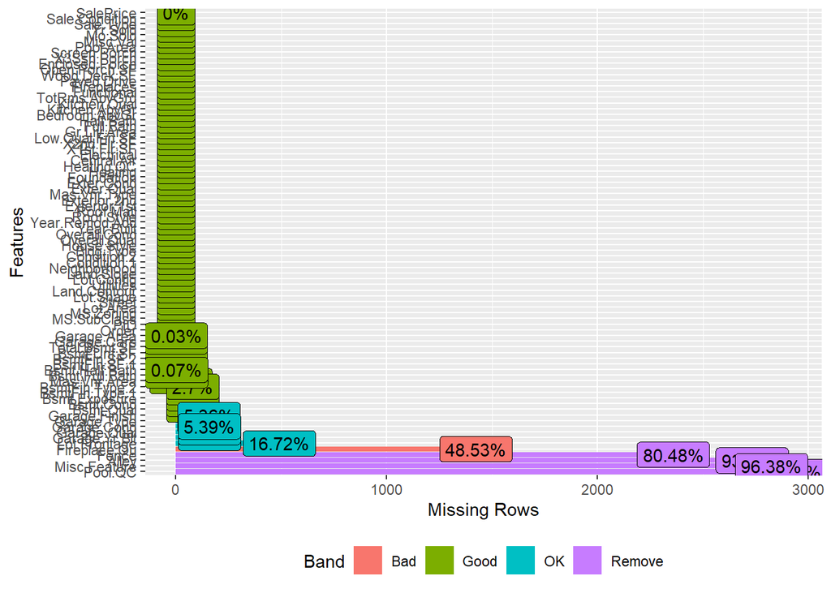

```r
plot_missing(df)
```

Below is a brief glimpse at the data. You can see the first and last 6 rows of data.

```r
head(df)
```

|  | Order | PID | MS.SubClass | MS.Zoning | Lot.Frontage | Lot.Area | Street | Alley | Lot.Shape | Land.Contour | Utilities | Lot.Config | Land.Slope | Neighborhood | Condition.1 | Condition.2 | Bldg.Type | House.Style | Overall.Qual | Overall.Cond | Year.Built | Year.Remod.Add | Roof.Style | Roof.Matl | Exterior.1st | Exterior.2nd | Mas.Vnr.Type | Mas.Vnr.Area | Exter.Qual | … |
| --- | --- | --- | --- | --- | --- | --- | --- | --- | --- | --- | --- | --- | --- | --- | --- | --- | --- | --- | --- | --- | --- | --- | --- | --- | --- | --- | --- | --- | --- | --- |
| 1 | 1 | 526301100 | 20 | RL | 141 | 31770 | Pave | NA | IR1 | Lvl | AllPub | Corner | Gtl | NAmes | Norm | Norm | 1Fam | 1Story | 6 | 5 | 1960 | 1960 | Hip | CompShg | BrkFace | Plywood | Stone | 112 | TA | … |
| 2 | 2 | 526350040 | 20 | RH | 80 | 11622 | Pave | NA | Reg | Lvl | AllPub | Inside | Gtl | NAmes | Feedr | Norm | 1Fam | 1Story | 5 | 6 | 1961 | 1961 | Gable | CompShg | VinylSd | VinylSd | None | 0 | TA | … |
| 3 | 3 | 526351010 | 20 | RL | 81 | 14267 | Pave | NA | IR1 | Lvl | AllPub | Corner | Gtl | NAmes | Norm | Norm | 1Fam | 1Story | 6 | 6 | 1958 | 1958 | Hip | CompShg | Wd Sdng | Wd Sdng | BrkFace | 108 | TA | … |
| 4 | 4 | 526353030 | 20 | RL | 93 | 11160 | Pave | NA | Reg | Lvl | AllPub | Corner | Gtl | NAmes | Norm | Norm | 1Fam | 1Story | 7 | 5 | 1968 | 1968 | Hip | CompShg | BrkFace | BrkFace | None | 0 | Gd | … |
| 5 | 5 | 527105010 | 60 | RL | 74 | 13830 | Pave | NA | IR1 | Lvl | AllPub | Inside | Gtl | Gilbert | Norm | Norm | 1Fam | 2Story | 5 | 5 | 1997 | 1998 | Gable | CompShg | VinylSd | VinylSd | None | 0 | TA | … |
| 6 | 6 | 527105030 | 60 | RL | 78 | 9978 | Pave | NA | IR1 | Lvl | AllPub | Inside | Gtl | Gilbert | Norm | Norm | 1Fam | 2Story | 6 | 6 | 1998 | 1998 | Gable | CompShg | VinylSd | VinylSd | BrkFace | 20 | TA | … |

```r
tail(df)
```

|  | Order | PID | MS.SubClass | MS.Zoning | Lot.Frontage | Lot.Area | Street | Alley | Lot.Shape | Land.Contour | Utilities | Lot.Config | Land.Slope | Neighborhood | Condition.1 | Condition.2 | Bldg.Type | House.Style | Overall.Qual | Overall.Cond | Year.Built | Year.Remod.Add | Roof.Style | Roof.Matl | Exterior.1st | Exterior.2nd | Mas.Vnr.Type | Mas.Vnr.Area | Exter.Qual | … |
| --- | --- | --- | --- | --- | --- | --- | --- | --- | --- | --- | --- | --- | --- | --- | --- | --- | --- | --- | --- | --- | --- | --- | --- | --- | --- | --- | --- | --- | --- | --- |
| 2925 | 2925 | 923251180 | 20 | RL | 160 | 20000 | Pave | NA | Reg | Lvl | AllPub | Inside | Gtl | Mitchel | Norm | Norm | 1Fam | 1Story | 5 | 7 | 1960 | 1996 | Gable | CompShg | VinylSd | VinylSd | None | 0 | TA | … |
| 2926 | 2926 | 923275080 | 80 | RL | 37 | 7937 | Pave | NA | IR1 | Lvl | AllPub | CulDSac | Gtl | Mitchel | Norm | Norm | 1Fam | SLvl | 6 | 6 | 1984 | 1984 | Gable | CompShg | HdBoard | HdBoard | None | 0 | TA | … |
| 2927 | 2927 | 923276100 | 20 | RL | NA | 8885 | Pave | NA | IR1 | Low | AllPub | Inside | Mod | Mitchel | Norm | Norm | 1Fam | 1Story | 5 | 5 | 1983 | 1983 | Gable | CompShg | HdBoard | HdBoard | None | 0 | TA | … |
| 2928 | 2928 | 923400125 | 85 | RL | 62 | 10441 | Pave | NA | Reg | Lvl | AllPub | Inside | Gtl | Mitchel | Norm | Norm | 1Fam | SFoyer | 5 | 5 | 1992 | 1992 | Gable | CompShg | HdBoard | Wd Shng | None | 0 | TA | … |
| 2929 | 2929 | 924100070 | 20 | RL | 77 | 10010 | Pave | NA | Reg | Lvl | AllPub | Inside | Mod | Mitchel | Norm | Norm | 1Fam | 1Story | 5 | 5 | 1974 | 1975 | Gable | CompShg | HdBoard | HdBoard | None | 0 | TA | … |
| 2930 | 2930 | 924151050 | 60 | RL | 74 | 9627 | Pave | NA | Reg | Lvl | AllPub | Inside | Mod | Mitchel | Norm | Norm | 1Fam | 2Story | 7 | 5 | 1993 | 1994 | Gable | CompShg | HdBoard | HdBoard | BrkFace | 94 | TA | … |

## 0.3 Data Preprocessing

### 0.3.1 Feature Generation

- The original pool variables of Pool.QC and Pool.Area were removed from the data since the majority of the values were missing. These variables were instead transformed into an indicator on whether or not the house has a pool.
- The Misc.Feature variable was also transformed into an indicator of whether the house has a shed, since 96.38% of the values were missing and shed was the most often seen Misc.Feature.

```r
#pool
df$Pool.QC<-as.factor(df$Pool.QC)
df$pool<-!is.na(df$Pool.QC)
df$pool<-as.factor(df$pool)

#misc feature
df$Misc.Feature<-as.factor(df$Misc.Feature)
df$shed<-recode_factor(df$Misc.Feature,
       "Elev"="No","Gar2"="No", "Othr"="No","TenC"="No", "Shed"="Yes")
df$shed[is.na(df$shed)]<-"No"
```

### 0.3.2 Imputing Values

- Lot area has no NA values and no 0 values. Since lot frontage is the width of a lot, this value also cannot be 0 or NA. As a result, the median value is imputed for the NA values present, which likely represent a data collection error.
- Garage.Cond,Garage.Finish,Garage.Qual, and Garage.Type all have empty spaces and NA values transformed into “NoGarage” level
- Garage.Area and Garage.Cars have NA values transformed into 0s.
- Garage.Yr.Blt has NA values imputed with the median and the max value of 2207 is transformed into 2007 since that was the date used in the remodel and selling year for that row and 2207 is not possible.
- Bsmt.Cond,Bsmt.Qual,Bsmt.Exposure,BsmtFin.Type.1, and BsmtFin.Type.2 have empty spaces and NA values transformed into “NoBsmt” level.
- Bsmt.Full.Bath,Half.Bath,Bsmt.Unf.SF,Total.Bsmt.SF,BsmtFin.SF.1,BsmtFin.SF.2, and Mas.Vnr.Area have NA values transformed into 0s.

```r
#lot
df$M_LotFrontage<-as.factor(ifelse(is.na(df$Lot.Frontage),1,0))
df$Lot.Frontage[is.na(df$Lot.Frontage)]<-median(df$Lot.Frontage, na.rm=TRUE)

#Garages
df$Garage.Area<-ifelse(is.na(df$Garage.Area),0, df$Garage.Area)
df$Garage.Cars<-ifelse(is.na(df$Garage.Cars),0, df$Garage.Cars)

df$Garage.Cond[df$Garage.Cond==""]<-NA
df$Garage.Cond[is.na(df$Garage.Cond)]<-"NoGarage"
df$Garage.Cond<-as.factor(df$Garage.Cond)

df$Garage.Finish[df$Garage.Finish==""]<-NA
df$Garage.Finish[is.na(df$Garage.Finish)]<-"NoGarage"
df$Garage.Finish<-as.factor(df$Garage.Finish)

df$Garage.Qual[df$Garage.Qual==""]<-NA
df$Garage.Qual[is.na(df$Garage.Qual)]<-"NoGarage"
df$Garage.Qual<-as.factor(df$Garage.Qual)

df$Garage.Type[df$Garage.Type==""]<-NA
df$Garage.Type[is.na(df$Garage.Type)]<-"NoGarage"
df$Garage.Type<-as.factor(df$Garage.Type)


df$Garage<-as.factor(ifelse(is.na(df$Garage.Yr.Blt),"No","Yes"))
df$Garage.Yr.Blt[is.na(df$Garage.Yr.Blt)]<-median(df$Garage.Yr.Blt, na.rm = TRUE)
df$Garage.Yr.Blt[df$Garage.Yr.Blt == 2207] <- 2007

#Basement
df$Bsmt.Cond[df$Bsmt.Cond==""]<-NA
df$Bsmt.Cond[is.na(df$Bsmt.Cond)]<-"NoBsmt"
df$Bsmt.Cond<-as.factor(df$Bsmt.Cond)

df$Bsmt.Qual[df$Bsmt.Qual==""]<-NA
df$Bsmt.Qual[is.na(df$Bsmt.Qual)]<-"NoBsmt"
df$Bsmt.Qual<-as.factor(df$Bsmt.Qual)

df$Bsmt.Exposure[df$Bsmt.Exposure==""]<-NA
df$Bsmt.Exposure[is.na(df$Bsmt.Exposure)]<-"NoBsmt"
df$Bsmt.Exposure<-as.factor(df$Bsmt.Exposure)

df$BsmtFin.Type.1[df$BsmtFin.Type.1==""]<-NA
df$BsmtFin.Type.1[is.na(df$BsmtFin.Type.1)]<-"NoBsmt"
df$BsmtFin.Type.1<-as.factor(df$BsmtFin.Type.1)

df$BsmtFin.Type.2[df$BsmtFin.Type.2==""]<-NA
df$BsmtFin.Type.2[is.na(df$BsmtFin.Type.2)]<-"NoBsmt"
df$BsmtFin.Type.2<-as.factor(df$BsmtFin.Type.2)

df$Bsmt.Full.Bath<-ifelse(is.na(df$Bsmt.Full.Bath),0, df$Bsmt.Full.Bath)
df$Bsmt.Half.Bath<-ifelse(is.na(df$Bsmt.Half.Bath),0, df$Bsmt.Half.Bath)

df$Bsmt.Unf.SF<-ifelse(is.na(df$Bsmt.Unf.SF),0, df$Bsmt.Unf.SF)

df$Total.Bsmt.SF<-ifelse(is.na(df$Total.Bsmt.SF),0, df$Total.Bsmt.SF)

df$BsmtFin.SF.1<-ifelse(is.na(df$BsmtFin.SF.1),0, df$BsmtFin.SF.1)
df$BsmtFin.SF.2<-ifelse(is.na(df$BsmtFin.SF.2),0, df$BsmtFin.SF.2)


#other
df$Mas.Vnr.Area<-ifelse(is.na(df$Mas.Vnr.Area),0, df$Mas.Vnr.Area)
```

### 0.3.3 Cleaning Variables

- Alley was recoded to signify whether or not the house had an alley since 93.24% of the data was missing.
- Fence was recoded to signify whether or not the house had an fence since 80.48% of the data was missing.
- Due to high degree of missing values in Fireplace.Qu (48.53%) and similar information stored in Fireplaces value, this column is dropped.
- PID is dropped since it is not useful for prediction.
- All character variables are transformed into factors.

```r
#alley
df$Alley[is.na(df$Alley)]<-"No"
df$Alley<-as.factor(df$Alley)
df$Alley<-recode_factor(df$Alley,
                       "Grvl"="Yes","Pave"="Yes")

#fence
df$Fence[is.na(df$Fence)]<-"No"
df$Fence<-as.factor(df$Fence)
df$Fence<-recode_factor(df$Fence,
                       "GdPrv"="Yes","GdWo"="Yes", "MnPrv"="Yes","MnWw"="Yes")

#Var removal
df.clean<-select(df, -Pool.QC, -Pool.Area, -Misc.Feature,-Fireplace.Qu, -PID)

df.clean[sapply(df.clean, is.character)] <- lapply(df.clean[sapply(df.clean, is.character)],
                                       as.factor)
```

### 0.3.4 Review Missingness

After cleaning, all missing values have been removed or transformed.

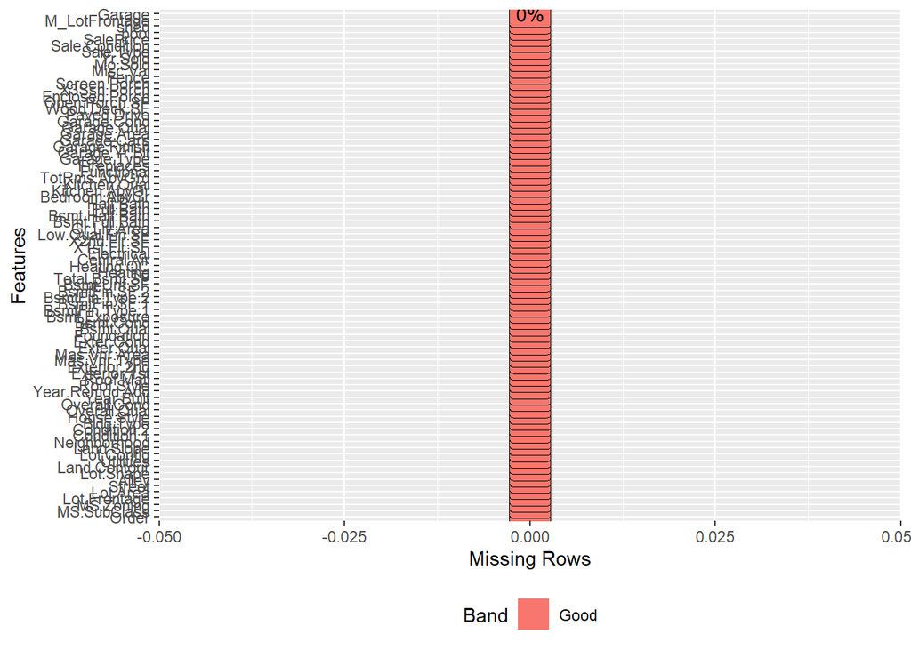

```r
plot_missing(df.clean)
```

## 0.4 Visualizations

In order to examine if location has influences home price, we first need to understand more about the distribution of location in the data. Below are graphs showing the number of homes sold by neighborhood and the average home sale price by neighborhood.

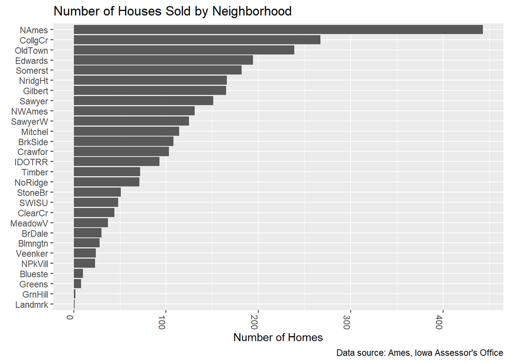

```r
df.clean %>%
  group_by(Neighborhood) %>%
  summarise(cnt = n()) %>%
  ggplot(aes(cnt,fct_reorder(Neighborhood,cnt))) +
  geom_bar(stat = "identity") +
  theme(axis.text.x=element_text(angle = -90, hjust = 0))+
  scale_y_discrete(name=element_blank()) +
  scale_x_continuous(name="Number of Homes")+
  labs(title="Number of Houses Sold by Neighborhood",
       caption="Data source: Ames, Iowa Assessor's Office")
```

The data was collected based on houses that were being sold in this area, which means it is a not a representative sample of the local real estate market in Ames, Iowa. This could skew average home sale price by neighborhood and impact the explanatory ability of our model.

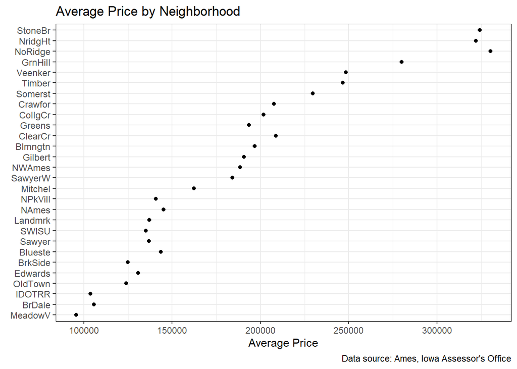

```r
df.clean %>%
  ggplot(aes(SalePrice, fct_reorder(Neighborhood,SalePrice))) +
  stat_summary(fun = "mean", geom="point") +
  theme(text = element_text(6),
        axis.text.y = element_text(6)) +
  scale_y_discrete(name=element_blank()) +
  scale_x_continuous(name="Average Price")+
  labs(title="Average Price by Neighborhood",
       caption="Data source: Ames, Iowa Assessor's Office") +
  theme_bw() +
  theme(axis.text.y=element_text(size=9))
```

While intially there does appear to be a difference in average price based on neighborhood, additional analysis will need to be conducted before concluding that neighborhood has a significant impact when predicting house selling price.

## 0.5 Model Creation

Stepwise regression was chosen instead of best subsets to complete this analysis since it is more compuational feasible given the quantity of variables present in the data. Two regressions were created, the first with neighborhood as a variable used for prediction and one without neighborhood. This was done in an effort to determine what impact neighborhood, and by extension location, had on home selling price.

```r
set.seed(101)

#Stepwise model with neighborhood
full.1<-lm(SalePrice~., data=df.clean, family="binomial")
null.1<-lm(SalePrice~1, data=df.clean, family="binomial")
step.1<-step(null.1, list(lower=formula(null.1), upper=formula(full.1)), data=df.clean, direction="both", trace=0)
#adjusted Rsquared = 0.9175, significant p-value


#without location, compare to see the impact
df.noLocation<-select(df.clean, -Neighborhood)
full.2<-lm(SalePrice~., data=df.noLocation, family="binomial")
null.2<-lm(SalePrice~1, data=df.noLocation, family="binomial")
step.2<-step(null.2, list(lower=formula(null.2), upper=formula(full.2)), data=df.noLocation, direction="both", trace=0)
#adjusted Rsquared = 0.9061, signifcant p-value
```

## 0.6 Model Comparison

As you can see below, both models do well at predicting SalePrice with adjusted R squared values of 0.92 and 0.91 respectively. This means that only about 1% of the unique sample variation in SalePrice can be explained by neighborhood for this given area.

However, for the first model, we can conclude that about 92% of the sample variation in SalePrice can be explained when using the variables listed below.

### 0.6.1 Model 1

```r
summ(step.1)
```

| Observations | 2930 |
| --- | --- |
| Dependent variable | SalePrice |
| Type | OLS linear regression |

| F(171,2758) | 193.45 |
| --- | --- |
| R² | 0.92 |
| Adj. R² | 0.92 |

|  | Est. | S.E. | t val. | p |
| --- | --- | --- | --- | --- |
| (Intercept) | -406016.86 | 688276.42 | -0.59 | 0.56 |
| Overall.Qual | 7059.21 | 660.07 | 10.69 | 0.00 |
| Gr.Liv.Area | 43.55 | 2.97 | 14.64 | 0.00 |
| NeighborhoodBlueste | -6156.76 | 8982.42 | -0.69 | 0.49 |
| NeighborhoodBrDale | 2247.21 | 7317.57 | 0.31 | 0.76 |
| NeighborhoodBrkSide | -10297.67 | 6020.83 | -1.71 | 0.09 |
| NeighborhoodClearCr | -11589.23 | 6542.54 | -1.77 | 0.08 |
| NeighborhoodCollgCr | -11081.30 | 5155.08 | -2.15 | 0.03 |
| NeighborhoodCrawfor | 3334.04 | 5832.19 | 0.57 | 0.57 |
| NeighborhoodEdwards | -21533.01 | 5522.62 | -3.90 | 0.00 |
| NeighborhoodGilbert | -14930.07 | 5351.79 | -2.79 | 0.01 |
| NeighborhoodGreens | 388.91 | 9886.79 | 0.04 | 0.97 |
| NeighborhoodGrnHill | 100629.96 | 17169.98 | 5.86 | 0.00 |
| NeighborhoodIDOTRR | -18423.16 | 6141.91 | -3.00 | 0.00 |
| NeighborhoodLandmrk | -1543.72 | 23639.91 | -0.07 | 0.95 |
| NeighborhoodMeadowV | -5224.07 | 7240.46 | -0.72 | 0.47 |
| NeighborhoodMitchel | -18767.42 | 5621.32 | -3.34 | 0.00 |
| NeighborhoodNAmes | -16619.03 | 5439.33 | -3.06 | 0.00 |
| NeighborhoodNoRidge | 26826.93 | 5928.85 | 4.52 | 0.00 |
| NeighborhoodNPkVill | 6974.14 | 7429.54 | 0.94 | 0.35 |
| NeighborhoodNridgHt | 18390.51 | 5331.34 | 3.45 | 0.00 |
| NeighborhoodNWAmes | -20428.49 | 5630.19 | -3.63 | 0.00 |
| NeighborhoodOldTown | -21209.16 | 5799.87 | -3.66 | 0.00 |
| NeighborhoodSawyer | -13519.93 | 5666.87 | -2.39 | 0.02 |
| NeighborhoodSawyerW | -11879.02 | 5458.30 | -2.18 | 0.03 |
| NeighborhoodSomerst | 8331.09 | 5231.29 | 1.59 | 0.11 |
| NeighborhoodStoneBr | 34958.05 | 5924.02 | 5.90 | 0.00 |
| NeighborhoodSWISU | -13115.65 | 6537.63 | -2.01 | 0.04 |
| NeighborhoodTimber | -11045.30 | 5680.75 | -1.94 | 0.05 |
| NeighborhoodVeenker | -12525.10 | 7060.22 | -1.77 | 0.08 |

[output cut: 145 more lines]

Standard errors: OLS

### 0.6.2 Model 2

```r
summ(step.2)
```

| Observations | 2930 |
| --- | --- |
| Dependent variable | SalePrice |
| Type | OLS linear regression |

| F(147,2782) | 193.22 |
| --- | --- |
| R² | 0.91 |
| Adj. R² | 0.91 |

|  | Est. | S.E. | t val. | p |
| --- | --- | --- | --- | --- |
| (Intercept) | 16845756.36 | 3782495.12 | 4.45 | 0.00 |
| Overall.Qual | 9042.43 | 678.84 | 13.32 | 0.00 |
| Gr.Liv.Area | 47.40 | 3.06 | 15.47 | 0.00 |
| Bsmt.QualFa | -19361.67 | 4138.04 | -4.68 | 0.00 |
| Bsmt.QualGd | -24386.30 | 2295.07 | -10.63 | 0.00 |
| Bsmt.QualNoBsmt | 6216.89 | 30225.59 | 0.21 | 0.84 |
| Bsmt.QualPo | -13668.42 | 19068.93 | -0.72 | 0.47 |
| Bsmt.QualTA | -23042.80 | 2895.56 | -7.96 | 0.00 |
| BsmtFin.SF.1 | 17.93 | 1.95 | 9.17 | 0.00 |
| Roof.MatlCompShg | 685443.75 | 29134.55 | 23.53 | 0.00 |
| Roof.MatlMembran | 758016.44 | 41200.83 | 18.40 | 0.00 |
| Roof.MatlMetal | 751618.75 | 40728.56 | 18.45 | 0.00 |
| Roof.MatlRoll | 675861.60 | 38477.78 | 17.56 | 0.00 |
| Roof.MatlTar&Grv | 697838.25 | 30776.78 | 22.67 | 0.00 |
| Roof.MatlWdShake | 680330.14 | 30737.85 | 22.13 | 0.00 |
| Roof.MatlWdShngl | 743664.44 | 30670.28 | 24.25 | 0.00 |
| Exter.QualFa | -16446.76 | 6319.09 | -2.60 | 0.01 |
| Exter.QualGd | -21690.03 | 3458.30 | -6.27 | 0.00 |
| Exter.QualTA | -27071.70 | 3850.19 | -7.03 | 0.00 |
| Bsmt.ExposureGd | 8499.23 | 2103.07 | 4.04 | 0.00 |
| Bsmt.ExposureMn | -6272.06 | 2149.29 | -2.92 | 0.00 |
| Bsmt.ExposureNo | -6584.06 | 1588.19 | -4.15 | 0.00 |
| Bsmt.ExposureNoBsmt | -3763.78 | 14300.05 | -0.26 | 0.79 |
| Garage.Area | 21.19 | 5.17 | 4.10 | 0.00 |
| Kitchen.QualFa | -22268.97 | 4296.07 | -5.18 | 0.00 |
| Kitchen.QualGd | -23128.18 | 2540.81 | -9.10 | 0.00 |
| Kitchen.QualPo | 9881.49 | 25306.39 | 0.39 | 0.70 |
| Kitchen.QualTA | -24343.49 | 2827.56 | -8.61 | 0.00 |
| Misc.Val | -10.86 | 0.89 | -12.25 | 0.00 |
| Year.Built | 299.20 | 42.60 | 7.02 | 0.00 |

[output cut: 119 more lines]

Standard errors: OLS

## 0.7 Model 1 Residual Analysis

### 0.7.1 Residuals vs Fitted

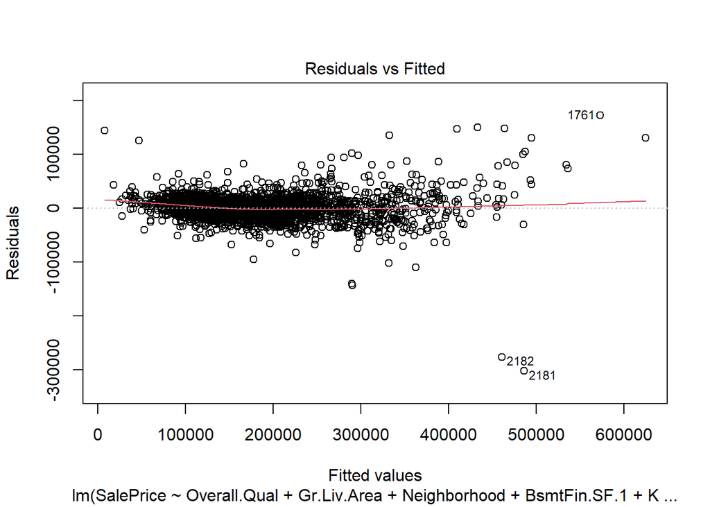

```r
plot(step.1, which=c(1))
```

While there does appear to be a slight pattern here, it does not appear that constant variance is serious issue for this model.

### 0.7.2 Normal Q-Q Plot

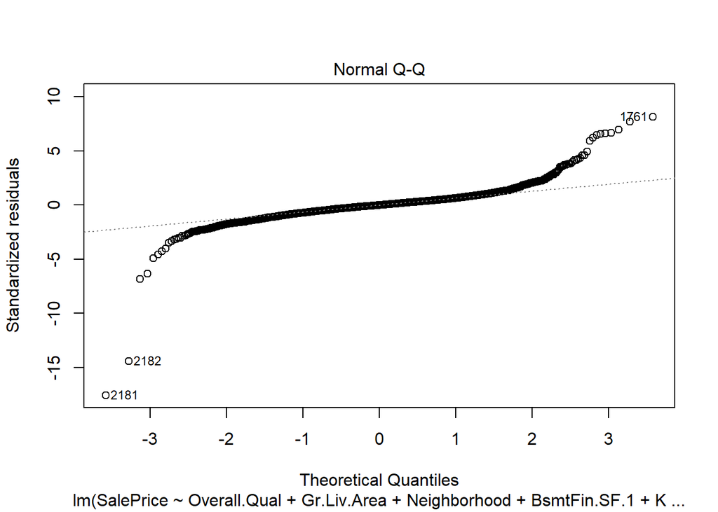

```r
plot(step.1, which=c(2))
```

### 0.7.3 Residuals vs Leverage

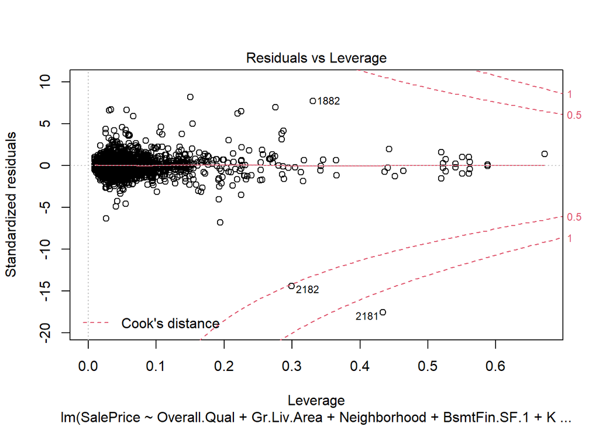

```r
plot(step.1, which=c(5))
```

Observations 2181 and 2182 are influential points and should be removed before creating the final model.

## 0.8 Model Revision

Final stepwise model is built after removing outliers, which improves overall predictive ability by raising the adjusted R squared value to 0.94, meaning that about 94% of the sample variation present in SalePrice is explained by this final model.

```r
remove<-c(2181,2182)
df.final<-df.clean[-remove,]


#Final stepwise model
full.3<-lm(SalePrice~., data=df.final, family="binomial")
null.3<-lm(SalePrice~1, data=df.final, family="binomial")
step.3<-step(null.3, list(lower=formula(null.3), upper=formula(full.3)), data=df.final, direction="both", trace=0)
```

```r
summ(step.3)
```

| Observations | 2928 |
| --- | --- |
| Dependent variable | SalePrice |
| Type | OLS linear regression |

| F(175,2752) | 241.99 |
| --- | --- |
| R² | 0.94 |
| Adj. R² | 0.94 |

|  | Est. | S.E. | t val. | p |
| --- | --- | --- | --- | --- |
| (Intercept) | -1579303.45 | 104315.43 | -15.14 | 0.00 |
| Overall.Qual | 6549.13 | 588.68 | 11.13 | 0.00 |
| Gr.Liv.Area | 36.36 | 9.80 | 3.71 | 0.00 |
| NeighborhoodBlueste | -805.76 | 8093.01 | -0.10 | 0.92 |
| NeighborhoodBrDale | 3566.61 | 6543.02 | 0.55 | 0.59 |
| NeighborhoodBrkSide | -6592.98 | 5377.64 | -1.23 | 0.22 |
| NeighborhoodClearCr | -12747.63 | 5788.26 | -2.20 | 0.03 |
| NeighborhoodCollgCr | -12120.04 | 4593.41 | -2.64 | 0.01 |
| NeighborhoodCrawfor | 3316.16 | 5199.52 | 0.64 | 0.52 |
| NeighborhoodEdwards | -15744.06 | 4924.12 | -3.20 | 0.00 |
| NeighborhoodGilbert | -14638.67 | 4784.12 | -3.06 | 0.00 |
| NeighborhoodGreens | 4470.68 | 8904.40 | 0.50 | 0.62 |
| NeighborhoodGrnHill | 95339.57 | 15411.88 | 6.19 | 0.00 |
| NeighborhoodIDOTRR | -14995.93 | 5488.71 | -2.73 | 0.01 |
| NeighborhoodLandmrk | -6078.80 | 21103.78 | -0.29 | 0.77 |
| NeighborhoodMeadowV | -7011.54 | 6471.85 | -1.08 | 0.28 |
| NeighborhoodMitchel | -18872.16 | 5003.70 | -3.77 | 0.00 |
| NeighborhoodNAmes | -14037.47 | 4856.36 | -2.89 | 0.00 |
| NeighborhoodNoRidge | 19008.42 | 5288.04 | 3.59 | 0.00 |
| NeighborhoodNPkVill | 10698.66 | 6666.43 | 1.60 | 0.11 |
| NeighborhoodNridgHt | 10923.33 | 4758.18 | 2.30 | 0.02 |
| NeighborhoodNWAmes | -18864.22 | 5030.46 | -3.75 | 0.00 |
| NeighborhoodOldTown | -18075.41 | 5167.49 | -3.50 | 0.00 |
| NeighborhoodSawyer | -9576.18 | 5050.83 | -1.90 | 0.06 |
| NeighborhoodSawyerW | -12952.91 | 4855.79 | -2.67 | 0.01 |
| NeighborhoodSomerst | 4108.68 | 4635.60 | 0.89 | 0.38 |
| NeighborhoodStoneBr | 27771.71 | 5296.02 | 5.24 | 0.00 |
| NeighborhoodSWISU | -11977.21 | 5809.57 | -2.06 | 0.04 |
| NeighborhoodTimber | -12932.58 | 5080.33 | -2.55 | 0.01 |
| NeighborhoodVeenker | -16071.83 | 6296.88 | -2.55 | 0.01 |

[output cut: 149 more lines]

Standard errors: OLS

## 0.9 Conclusions

The final stepwise model created will be able to predict future house prices after inputting the same house characteristics. This will allow for realtors in Ames, Iowa to provide a reasonable price point when buying homes or consulting with families who own a home on what their house is worth. In addition, by using this model realtors can see which factors influence home prices in this area, such as the overall material and finish of the house, which can be used for consultations regarding home value improvement projects or internal company projects to increase the value of their assets. This model will also allow the company to streamline their pricing process, which will likely increase customer satisfaction and potentially attract new customers to their company.

While there are clear differences in average home price for different neighborhoods, neighborhood when used as a predictor for SalePrice only marginally increases the models ability to explain the sample variation in SalePrice. As a result, realtors in this area should focus on the actual characteristics of a given house before considering location when attempting to discover undervalued real estate in the area.